# Exercise 7: Debt Resolution Mechanisms

BP3 — Fund’s Role in International Debt Architecture

# Setup

```r
# Load individual packages (tidyverse meta-package not available on this machine)
library(dplyr)
library(tidyr)
library(ggplot2)
library(purrr)
library(stringr)
library(openxlsx)
library(scales)
cat("Libraries loaded\n")
```

```r
# --- Paths ---
# On this WSL machine:
ids_dir             <- "../ids"
characteristics_dir <- "."
output_dir          <- "output/ex7"

# On the IMF laptop swap the three lines above for:
#   ids_dir             <- "C:/Users/gsoto/International Monetary Fund (PRD)/IEO-DIL - Documents/Data/WB IDS/WB IDS25"
#   characteristics_dir <- "U:/dil/main-characteristics"
#   output_dir          <- "U:/dil/bp3/output/ex7"

dir.create(output_dir, recursive = TRUE, showWarnings = FALSE)
cat("Output dir ready:", output_dir, "\n")
```

# 1. Load IDS data (6 Excel files)

IDS 2025 is distributed as 6 Excel files split alphabetically by country name (A_D, E_K, L_M, N_Q, R_U, V_Z). We load all six, coerce year columns to character to avoid type-mismatch on bind, then combine into one raw frame.

```r
files <- c("A_D.xlsx", "E_K.xlsx", "L_M.xlsx", "N_Q.xlsx", "R_U.xlsx", "V_Z.xlsx")

ids_list <- list()
for (f in files) {
  cat("Loading", f, "...\n")
  ids_list[[f]] <- read.xlsx(file.path(ids_dir, f))
  cat("  rows:", format(nrow(ids_list[[f]]), big.mark = ","), "\n")
}

# Coerce year columns to character before binding to avoid integer/double mismatch
year_cols <- names(ids_list[[1]])[grepl("^\\d{4}$", names(ids_list[[1]]))]
for (i in seq_along(ids_list)) {
  ids_list[[i]][year_cols] <- lapply(ids_list[[i]][year_cols], as.character)
}

ids_raw <- bind_rows(ids_list)
rm(ids_list); gc()

cat("\n--- Load summary ---\n")
cat("Total rows:", format(nrow(ids_raw), big.mark = ","), "\n")
cat("Countries:", n_distinct(ids_raw$Country.Name), "\n")
cat("Series codes:", n_distinct(ids_raw$Series.Code), "\n")
cat("Counterpart areas:", n_distinct(ids_raw[["Counterpart-Area.Code"]]), "\n")
```

# 2. Filter to the 7 series we need

We need exactly 7 series. Each series and its role:

| Series code | What it measures | Role in exercise |
| --- | --- | --- |
| DT.DOD.BLAT.CD | PPG bilateral debt by creditor country | PC / non-PC split |
| DT.DOD.MLAT.CD | PPG multilateral debt | Always outside |
| DT.DOD.PBND.CD | PPG bonds (eurobonds, etc.) | Covered from 2003 (CACs) |
| DT.DOD.PCBK.CD | PPG commercial bank loans | Covered from 1976 (London Club) |
| DT.DOD.PROP.CD | PPG other private creditors | Always outside (no mechanism) |
| DT.DOD.DPPG.CD | Total PPG debt | Denominator (base) |
| DT.DOD.DIMF.CD | IMF credit (use of Fund resources) | Always outside; added to denominator |

IMPORTANT: private debt is stored in SEPARATE series (PBND, PCBK, PROP). Do NOT try to get bonds/banks from DT.DOD.PRVT.CD by counterpart filtering — that does not work in IDS 2025.

```r
keep_series <- c(
  "DT.DOD.BLAT.CD",   # bilateral (counterpart-level rows let us identify PC creditors)
  "DT.DOD.MLAT.CD",   # multilateral total
  "DT.DOD.PBND.CD",   # PPG bonds
  "DT.DOD.PCBK.CD",   # PPG commercial bank loans
  "DT.DOD.PROP.CD",   # PPG other private creditors (always outside)
  "DT.DOD.DPPG.CD",   # total PPG (denominator base)
  "DT.DOD.DIMF.CD"    # IMF credit
)

ids_raw <- ids_raw %>% filter(Series.Code %in% keep_series)

cat("Rows after series filter:", format(nrow(ids_raw), big.mark = ","), "\n\n")
cat("Series present in data:\n")
ids_raw %>%
  count(Series.Code, Series.Name) %>%
  as.data.frame() %>%
  print()
```

# 3. Remove regional and income-group aggregates

IDS includes non-country rows (e.g. “Low income”, “World”) that would distort country-level analysis. Remove them by name.

```r
remove_these <- c(
  "East Asia & Pacific (excluding high income)",
  "Europe & Central Asia (excluding high income)",
  "IDA only", "IDA total",
  "Latin America & Caribbean (excluding high income)",
  "Least developed countries: UN classification",
  "Low & middle income", "Low income", "Lower middle income",
  "Middle East & North Africa (excluding high income)",
  "Middle East, North Africa, Afghanistan & Pakistan (excluding high income)",
  "Middle income", "South Asia",
  "Sub-Saharan Africa (excluding high income)",
  "Upper middle income",
  "Heavily indebted poor countries (HIPC)",
  "World"
)

ids_raw <- ids_raw %>% filter(!Country.Name %in% remove_these)
cat("Countries remaining after removing aggregates:", n_distinct(ids_raw$Country.Name), "\n")
```

# 4. Reshape to long format

IDS is wide: one row per (country × series × counterpart), with a column per year. We pivot to long so each row = one country × series × counterpart × year observation. We also clean up column names and drop NA values.

```r
year_cols <- names(ids_raw)[grepl("^\\d{4}$", names(ids_raw))]

ids_long <- ids_raw %>%
  pivot_longer(
    cols      = all_of(year_cols),
    names_to  = "year",
    values_to = "value"
  ) %>%
  mutate(
    year  = as.integer(year),
    value = as.numeric(value)
  ) %>%
  # Keep 1970–2024 and drop missing values
  # We keep zeros here; we'll drop them at the panel-building stage
  filter(year >= 1970, year <= 2024, !is.na(value)) %>%
  rename(
    country_code = Country.Code,
    country_name = Country.Name,
    ca_name      = `Counterpart-Area.Name`,
    ca_code      = `Counterpart-Area.Code`,
    series_name  = Series.Name,
    series_code  = Series.Code
  ) %>%
  # Trim whitespace from codes (common issue in Excel exports)
  mutate(
    ca_code      = trimws(ca_code),
    country_code = trimws(country_code)
  )

rm(ids_raw); gc()

cat("--- Reshape summary ---\n")
cat("Rows:", format(nrow(ids_long), big.mark = ","), "\n")
cat("Year range:", min(ids_long$year), "-", max(ids_long$year), "\n")
cat("Countries:", n_distinct(ids_long$country_code), "\n")
cat("Series codes in data:\n")
ids_long %>% count(series_code) %>% as.data.frame() %>% print()
```

# 5. LIC / MIC classification

We add an income_group column (“LIC” or “MIC”) to every row using the country-characteristics file. We keep BOTH groups in the data throughout; the income_group column lets us aggregate separately at the chart stage.

```r
chars   <- read.xlsx(
  file.path(characteristics_dir, "country-characteristics.xlsx"),
  sheet = "main"
)

# Extract ISO codes of LIC countries from the characteristics file
lic_iso <- trimws(chars$iso)
lic_iso <- lic_iso[!is.na(lic_iso) & lic_iso != ""]

ids_long <- ids_long %>%
  mutate(income_group = if_else(country_code %in% lic_iso, "LIC", "MIC"))

cat("LIC countries:", n_distinct(ids_long$country_code[ids_long$income_group == "LIC"]), "\n")
cat("MIC countries:", n_distinct(ids_long$country_code[ids_long$income_group == "MIC"]), "\n")

# Countries in IDS that are not in the characteristics file → classified as MIC
unmatched_count <- n_distinct(ids_long$country_code[ids_long$income_group == "MIC" &
                                                       !ids_long$country_code %in% lic_iso])
cat("(Countries not in characteristics file, defaulted to MIC:", unmatched_count, ")\n")
```

# 6. Paris Club member mapping

The Paris Club (PC) is the group of official bilateral creditors that coordinates sovereign debt restructurings. We identify each member by their IDS counterpart area code (ca_code) and the year they formally joined the PC.

A country’s bilateral debt to a PC member is classified as “officially covered” (subject to the Paris Club mechanism) IF the observation year >= the creditor’s accession year. Debt to all other bilateral creditors (China, India, Gulf states, etc.) is “non-PC” and classified as outside the framework before 2020.

From 2020 onward, the Common Framework (CF) extends to ALL bilateral creditors, so we reclassify non-PC bilateral as covered from that year.

```r
pc_mapping <- tribble(
  ~ca_code,  ~pc_name,                ~accession_year,
  "801",     "Australia",             1956,
  "001",     "Austria",               1956,
  "002",     "Belgium",               1956,
  "301",     "Canada",                1956,
  "003",     "Denmark",               1956,
  "018",     "Finland",               1956,
  "004",     "France",                1956,
  "005",     "Germany, Fed. Rep.",    1956,
  "021",     "Ireland",               1956,
  "006",     "Italy",                 1956,
  "701",     "Japan",                 1956,
  "007",     "Netherlands",           1956,
  "008",     "Norway",                1956,
  "050",     "Spain",                 1956,
  "010",     "Sweden",                1956,
  "011",     "Switzerland",           1956,
  "012",     "United Kingdom",        1956,
  "302",     "United States",         1956,
  "087",     "Russian Federation",    1997,
  "546",     "Israel",                2014,
  "742",     "Korea, Republic of",    2016,
  "431",     "Brazil",                2016
)

cat("PC members in mapping:", nrow(pc_mapping), "\n\n")

# Verify how many of these ca_codes actually appear in the bilateral IDS data
blat_ca_present <- ids_long %>%
  filter(series_code == "DT.DOD.BLAT.CD") %>%
  distinct(ca_code)

matched   <- sum(pc_mapping$ca_code %in% blat_ca_present$ca_code)
unmatched <- pc_mapping$ca_code[!pc_mapping$ca_code %in% blat_ca_present$ca_code]

cat("PC codes matched in IDS bilateral data:", matched, "of", nrow(pc_mapping), "\n")
if (length(unmatched) > 0) {
  cat("Unmatched codes (these creditors reported 0 bilateral lending):",
      paste(unmatched, collapse = ", "), "\n")
}
```

# 7. Build the denominator

Denominator per country-year = Total PPG debt + IMF credit.

IDS reports IMF credit (DT.DOD.DIMF.CD) separately from PPG (DT.DOD.DPPG.CD) because IMF lending is not classified as external debt in the standard sense. We add both to capture the full external public obligation.

```r
KEY <- c("country_code", "country_name", "year", "income_group")

# Total PPG debt (sum of all bilateral + multilateral + private)
total_ppg <- ids_long %>%
  filter(series_code == "DT.DOD.DPPG.CD", ca_code == "WLD") %>%
  select(all_of(KEY), total_ppg = value)

# IMF credit
imf_denom <- ids_long %>%
  filter(series_code == "DT.DOD.DIMF.CD", ca_code == "WLD") %>%
  select(all_of(KEY), imf_value = value)

denominator <- total_ppg %>%
  left_join(imf_denom, by = KEY) %>%
  mutate(
    imf_value   = replace_na(imf_value, 0),
    denominator = total_ppg + imf_value
  ) %>%
  filter(denominator > 0)   # drop country-years with no debt

cat("Denominator rows:", nrow(denominator), "\n")
cat("Country-years covered:", n_distinct(paste(denominator$country_code, denominator$year)), "\n\n")

# Spot check: median total debt by year for LICs (sanity check — should grow over time)
cat("Median total debt (billion USD) for LICs at selected years:\n")
denominator %>%
  filter(income_group == "LIC",
         year %in% c(1970, 1980, 1990, 2000, 2010, 2020, 2023)) %>%
  group_by(year) %>%
  summarise(
    median_ppg_bn = round(median(total_ppg,  na.rm = TRUE) / 1e9, 2),
    median_imf_bn = round(median(imf_value,  na.rm = TRUE) / 1e9, 2),
    n_countries   = n()
  ) %>%
  as.data.frame() %>%
  print()
```

# 8. Build bilateral components: Paris Club vs. non-PC

We split bilateral debt into two components:

blat_pc: debt owed to Paris Club member countries blat_nonpc: debt owed to all other bilateral creditors (China, India, Gulf, etc.)

Method: - blat_total = WLD aggregate row of DT.DOD.BLAT.CD (total bilateral) - blat_pc = sum of individual creditor-country rows where ca_code is a PC member AND year >= that member’s accession year - blat_nonpc = blat_total - blat_pc (floored at 0 for data consistency)

```r
# Step A: total bilateral per country-year (WLD aggregate row)
blat_total <- ids_long %>%
  filter(series_code == "DT.DOD.BLAT.CD", ca_code == "WLD") %>%
  select(all_of(KEY), blat_total = value)

# Step B: PC bilateral — sum of individual PC-member creditor rows,
#          counting only years in which that creditor was already a PC member
blat_pc <- ids_long %>%
  filter(
    series_code == "DT.DOD.BLAT.CD",
    ca_code %in% pc_mapping$ca_code        # only rows for PC member countries
  ) %>%
  left_join(pc_mapping %>% select(ca_code, accession_year), by = "ca_code") %>%
  filter(year >= accession_year) %>%       # respect each member's join date
  group_by(across(all_of(KEY))) %>%
  summarise(blat_pc = sum(value, na.rm = TRUE), .groups = "drop")

# Step C: non-PC = total minus PC (pmax prevents negative values from data gaps)
bilateral <- blat_total %>%
  left_join(blat_pc, by = KEY) %>%
  mutate(
    blat_pc    = replace_na(blat_pc, 0),
    blat_nonpc = pmax(blat_total - blat_pc, 0)
  )

cat("Bilateral panel rows:", nrow(bilateral), "\n\n")

# Diagnostic: PC share of bilateral debt over time for LICs
# Expected pattern: high in 1970s (PC was the main bilateral lender),
#   declining from 2000s as China/others became large lenders,
#   but NOTE — the 2020 jump is NOT in this data; it comes from the case_when rule.
cat("PC share of total bilateral debt for LICs (%):\n")
bilateral %>%
  filter(income_group == "LIC", blat_total > 0,
         year %in% c(1970, 1975, 1980, 1985, 1990, 1995,
                     2000, 2005, 2010, 2015, 2020, 2023)) %>%
  group_by(year) %>%
  summarise(
    pc_share_pct = round(100 * sum(blat_pc) / sum(blat_total), 1),
    n_countries  = n()
  ) %>%
  as.data.frame() %>%
  print()
```

# 9. Build private and multilateral components

Private debt in IDS uses SEPARATE series per creditor type. We pull each one at the WLD aggregate level (ca_code == “WLD”).

PROP is kept SEPARATE from PCBK — do not merge them.

```r
# PPG bonds (eurobonds, sovereign commercial paper)
bonds <- ids_long %>%
  filter(series_code == "DT.DOD.PBND.CD", ca_code == "WLD") %>%
  select(all_of(KEY), value)

# Commercial bank loans (syndicated loans, bilateral bank lending)
banks <- ids_long %>%
  filter(series_code == "DT.DOD.PCBK.CD", ca_code == "WLD") %>%
  select(all_of(KEY), value)

# Other private creditors: suppliers, non-guaranteed export credits, etc.
# Rule: ALWAYS outside framework — no collective restructuring mechanism
other_private <- ids_long %>%
  filter(series_code == "DT.DOD.PROP.CD", ca_code == "WLD") %>%
  select(all_of(KEY), value)

# Total multilateral (all MFIs combined — both PCS and non-PCS)
multilateral <- ids_long %>%
  filter(series_code == "DT.DOD.MLAT.CD", ca_code == "WLD") %>%
  select(all_of(KEY), value)

# IMF credit (use of Fund resources — always outside, senior creditor)
imf_comp <- ids_long %>%
  filter(series_code == "DT.DOD.DIMF.CD", ca_code == "WLD") %>%
  select(all_of(KEY), value)

cat("Component rows loaded:\n")
cat("  Bonds (PBND):          ", nrow(bonds), "\n")
cat("  Banks (PCBK):          ", nrow(banks), "\n")
cat("  Other private (PROP):  ", nrow(other_private), "\n")
cat("  Multilateral (MLAT):   ", nrow(multilateral), "\n")
cat("  IMF credit (DIMF):     ", nrow(imf_comp), "\n")

# Spot check: median debt levels in 2010 for LICs — gives intuition for each component's size
cat("\nMedian debt by component, LICs in 2010 (billion USD):\n")
bind_rows(
  bonds         %>% mutate(type = "Bonds"),
  banks         %>% mutate(type = "Banks"),
  other_private %>% mutate(type = "Other Private"),
  multilateral  %>% mutate(type = "Multilateral"),
  imf_comp      %>% mutate(type = "IMF Credit")
) %>%
  filter(income_group == "LIC", year == 2010, value > 0) %>%
  group_by(type) %>%
  summarise(
    median_bn   = round(median(value, na.rm = TRUE) / 1e9, 3),
    n_countries = n()
  ) %>%
  arrange(desc(median_bn)) %>%
  as.data.frame() %>%
  print()
```

# 10. Stack all creditor types into one long panel

We combine all 7 creditor types into a single long dataframe where each row represents one country × year × creditor_type. This is the “raw panel” before mechanism classification.

We drop zero and NA values here to keep the panel lean (zeros don’t contribute to shares and inflate row counts without adding information).

```r
panel_long <- bind_rows(
  bilateral     %>% select(all_of(KEY), value = blat_pc)    %>% mutate(creditor_type = "Bilateral PC"),
  bilateral     %>% select(all_of(KEY), value = blat_nonpc) %>% mutate(creditor_type = "Bilateral Non-PC"),
  bonds         %>% mutate(creditor_type = "Bonds"),
  banks         %>% mutate(creditor_type = "Commercial Banks"),  # PCBK only
  other_private %>% mutate(creditor_type = "Other Private"),     # PROP: always outside
  multilateral  %>% mutate(creditor_type = "Multilateral"),
  imf_comp      %>% mutate(creditor_type = "IMF Credit")
) %>%
  filter(!is.na(value), value > 0)  # keep only positive debt stocks

cat("Long panel rows:", format(nrow(panel_long), big.mark = ","), "\n\n")

cat("Row count by creditor type:\n")
panel_long %>%
  count(creditor_type) %>%
  mutate(pct = round(100 * n / sum(n), 1)) %>%
  as.data.frame() %>%
  print()
```

# 11. Apply resolution mechanism classification

This is the core step. We assign each row a mechanism label using case_when, then add a boolean `covered` flag.

Rules (from economist):

Bilateral PC → “Official covered (Paris Club / CF)” — always Bilateral Non-PC → “Official covered (Paris Club / CF)” — from 2020 (Common Framework) → “Official outside framework” — before 2020 Commercial Banks → “Private banks covered (London Club)” — 1976 to 2002 → “Private outside framework” — before 1976 OR from 2003 (London Club ceased when bonds/CACs became dominant) Bonds → “Bond debt covered (CACs)” — from 2003 → “Private outside framework” — before 2003 Other Private → “Private outside framework” — always (no mechanism) Multilateral + IMF → “Multilateral / IMF outside” — always (senior creditors)

```r
panel_classified <- panel_long %>%
  mutate(
    mechanism = case_when(
      # --- Official bilateral ---
      creditor_type == "Bilateral PC"                       ~ "Official covered (Paris Club / CF)",
      creditor_type == "Bilateral Non-PC" & year >= 2020   ~ "Official covered (Paris Club / CF)",
      creditor_type == "Bilateral Non-PC" & year <  2020   ~ "Official outside framework",

      # --- Private banks: London Club active 1976–2002; ceased from 2003 ---
      creditor_type == "Commercial Banks" & year >= 1976 & year < 2003 ~ "Private banks covered (London Club)",
      creditor_type == "Commercial Banks"                               ~ "Private outside framework",

      # --- Bonds: CACs became standard in 2003 ---
      creditor_type == "Bonds"            & year >= 2003   ~ "Bond debt covered (CACs)",
      creditor_type == "Bonds"            & year <  2003   ~ "Private outside framework",

      # --- Other private: no mechanism exists ---
      creditor_type == "Other Private"                     ~ "Private outside framework",

      # --- Multilateral + IMF: senior creditors, outside restructuring ---
      creditor_type %in% c("Multilateral", "IMF Credit")  ~ "Multilateral / IMF outside"
    ),

    # TRUE if this debt is under some restructuring mechanism; FALSE if outside
    covered = mechanism %in% c(
      "Official covered (Paris Club / CF)",
      "Private banks covered (London Club)",
      "Bond debt covered (CACs)"
    )
  )

# Diagnostic 1: full cross-tab of creditor_type × mechanism × covered
# Use this to VERIFY each type maps to exactly the right mechanism(s)
cat("=== Creditor type → Mechanism mapping ===\n")
```

```
=== Creditor type → Mechanism mapping ===
```

```r
cat("(Each creditor_type can map to 1 or 2 mechanisms depending on year)\n\n")
```

```
(Each creditor_type can map to 1 or 2 mechanisms depending on year)
```

```r
panel_classified %>%
  distinct(creditor_type, mechanism, covered) %>%
  arrange(creditor_type, mechanism) %>%
  as.data.frame() %>%
  print()
```

```
      creditor_type                           mechanism covered
1  Bilateral Non-PC  Official covered (Paris Club / CF)    TRUE
2  Bilateral Non-PC          Official outside framework   FALSE
3      Bilateral PC  Official covered (Paris Club / CF)    TRUE
4             Bonds            Bond debt covered (CACs)    TRUE
5             Bonds           Private outside framework   FALSE
6  Commercial Banks Private banks covered (London Club)    TRUE
7  Commercial Banks           Private outside framework   FALSE
8        IMF Credit          Multilateral / IMF outside   FALSE
9      Multilateral          Multilateral / IMF outside   FALSE
10    Other Private           Private outside framework   FALSE
```

```r
# Diagnostic 2: verify that the year-threshold switches happen at the RIGHT years
# Run this block to confirm 1976, 2003, and 2020 break points

cat("=== London Club switch: Commercial Banks should change mechanism AT 1976 ===\n")
```

```
=== London Club switch: Commercial Banks should change mechanism AT 1976 ===
```

```r
panel_classified %>%
  filter(creditor_type == "Commercial Banks",
         year %in% c(1974, 1975, 1976, 1977)) %>%
  count(year, mechanism, covered) %>%
  as.data.frame() %>%
  print()
```

```
  year                           mechanism covered  n
1 1974           Private outside framework   FALSE 51
2 1975           Private outside framework   FALSE 50
3 1976 Private banks covered (London Club)    TRUE 53
4 1977 Private banks covered (London Club)    TRUE 56
```

```r
cat("\n=== CAC switch: Bonds should change mechanism AT 2003 ===\n")
```

```
=== CAC switch: Bonds should change mechanism AT 2003 ===
```

```r
panel_classified %>%
  filter(creditor_type == "Bonds",
         year %in% c(2001, 2002, 2003, 2004)) %>%
  count(year, mechanism, covered) %>%
  as.data.frame() %>%
  print()
```

```
  year                 mechanism covered  n
1 2001 Private outside framework   FALSE 38
2 2002 Private outside framework   FALSE 38
3 2003  Bond debt covered (CACs)    TRUE 37
4 2004  Bond debt covered (CACs)    TRUE 37
```

```r
cat("\n=== Common Framework switch: Bilateral Non-PC should change AT 2020 ===\n")
```

```
=== Common Framework switch: Bilateral Non-PC should change AT 2020 ===
```

```r
panel_classified %>%
  filter(creditor_type == "Bilateral Non-PC",
         year %in% c(2018, 2019, 2020, 2021)) %>%
  count(year, mechanism, covered) %>%
  as.data.frame() %>%
  print()
```

```
  year                          mechanism covered   n
1 2018         Official outside framework   FALSE 115
2 2019         Official outside framework   FALSE 116
3 2020 Official covered (Paris Club / CF)    TRUE 116
4 2021 Official covered (Paris Club / CF)    TRUE 116
```

```r
# Diagnostic 3: aggregate covered vs outside for LICs at key years
# This is a simple summary (ignoring the 6-way breakdown) to build intuition
cat("=== Overall % of LIC debt that is COVERED at key years ===\n")
```

```
=== Overall % of LIC debt that is COVERED at key years ===
```

```r
cat("(Aggregate across all countries; not median — just for intuition)\n\n")
```

```
(Aggregate across all countries; not median — just for intuition)
```

```r
panel_classified %>%
  left_join(denominator %>% select(all_of(KEY), denominator), by = KEY) %>%
  filter(income_group == "LIC", !is.na(denominator), denominator > 0,
         year %in% c(1970, 1980, 1990, 2000, 2010, 2020, 2023)) %>%
  group_by(year, covered) %>%
  summarise(total_debt_bn = sum(value, na.rm = TRUE) / 1e9, .groups = "drop") %>%
  group_by(year) %>%
  mutate(share_pct = round(100 * total_debt_bn / sum(total_debt_bn), 1)) %>%
  filter(covered == TRUE) %>%
  select(year, covered_pct = share_pct) %>%
  as.data.frame() %>%
  print()
```

```
  year covered_pct
1 1970        41.5
2 1980        36.5
3 1990        36.3
4 2000        34.9
5 2010        18.5
6 2020        42.2
7 2023        38.0
```

# 12. Compute each mechanism’s share of total debt per country-year

For each country-year, divide each mechanism’s debt stock by the denominator (total PPG + IMF credit). The result is a % of total external public debt.

We group by mechanism (and covered) within country-year, summing across creditor_types that map to the same mechanism (e.g., Bilateral PC and Bilateral Non-PC both map to “Official covered” from 2020 onward).

```r
panel_shares <- panel_classified %>%
  left_join(denominator %>% select(all_of(KEY), denominator), by = KEY) %>%
  filter(!is.na(denominator), denominator > 0) %>%
  mutate(share = value / denominator * 100) %>%
  group_by(across(all_of(c(KEY, "mechanism", "covered")))) %>%
  summarise(share = sum(share, na.rm = TRUE), .groups = "drop")

cat("Panel shares rows:", format(nrow(panel_shares), big.mark = ","), "\n\n")
```

```
Panel shares rows: 24,045
```

```r
# Diagnostic: do component shares sum to ~100% per country-year?
# Some deviation is expected because IDS counterpart-level bilateral data
# may not perfectly sum to the WLD bilateral aggregate.
# The renormalization step later corrects for this at the chart stage.
cat("Do shares sum to ~100% per country-year? Distribution of row sums:\n")
```

```
Do shares sum to ~100% per country-year? Distribution of row sums:
```

```r
panel_shares %>%
  group_by(country_code, year) %>%
  summarise(total_share = sum(share, na.rm = TRUE), .groups = "drop") %>%
  filter(year %in% c(1990, 2000, 2010, 2020)) %>%
  group_by(year) %>%
  summarise(
    p10    = round(quantile(total_share, 0.10), 1),
    p25    = round(quantile(total_share, 0.25), 1),
    median = round(median(total_share), 1),
    p75    = round(quantile(total_share, 0.75), 1),
    p90    = round(quantile(total_share, 0.90), 1),
    .groups = "drop"
  ) %>%
  as.data.frame() %>%
  print()
```

```
  year p10 p25 median p75 p90
1 1990 100 100    100 100 100
2 2000 100 100    100 100 100
3 2010 100 100    100 100 100
4 2020 100 100    100 100 100
```

# 13. Annual median across countries + renormalize to 100%

Two steps:

Step 1 — Median: For each year × mechanism, take the MEDIAN share across countries. This gives equal weight to each country regardless of debt size. A “typical” country’s debt composition for that year.

Step 2 — Renormalize: Divide each mechanism’s median by the sum of all medians for that year, then multiply by 100. This corrects for the fact that IDS components don’t perfectly sum to the denominator at country level, and ensures the stacked chart always sums to exactly 100%.

We produce three aggregates: LIC-only, MIC-only, All (both groups).

```r
# In geom_area, the LAST factor level sits at the BOTTOM of the stack.
# List Multilateral first (top) and Official covered last (bottom).
mechs_ordered <- c(
  "Multilateral / IMF outside",            # first  → TOP of chart
  "Private outside framework",
  "Official outside framework",
  "Bond debt covered (CACs)",
  "Private banks covered (London Club)",
  "Official covered (Paris Club / CF)"     # last   → BOTTOM of chart
)

# Reusable function: aggregate one group, produce normalized annual data
aggregate_group <- function(data, group_label) {

  # Step 1: median per year × mechanism across countries
  annual <- data %>%
    group_by(year, mechanism) %>%
    summarise(
      median_share = median(share, na.rm = TRUE),
      n_countries  = n_distinct(country_code),
      .groups      = "drop"
    )

  # Ensure every year × mechanism combination is present (fill missing with 0)
  annual <- annual %>%
    complete(
      year      = 1970:2024,
      mechanism = mechs_ordered,
      fill      = list(median_share = 0, n_countries = 0)
    )

  # Step 2: renormalize to 100% per year
  annual <- annual %>%
    group_by(year) %>%
    mutate(
      row_sum  = sum(median_share, na.rm = TRUE),
      pct_norm = if_else(row_sum > 0, median_share / row_sum * 100, 0)
    ) %>%
    ungroup() %>%
    mutate(
      income_group = group_label,
      mechanism    = factor(mechanism, levels = mechs_ordered)
    )

  annual
}

annual_lic <- panel_shares %>% filter(income_group == "LIC") %>% aggregate_group("LIC")
annual_mic <- panel_shares %>% filter(income_group == "MIC") %>% aggregate_group("MIC")
annual_all <- panel_shares %>%                                   aggregate_group("All")

cat("Annual rows — LIC:", nrow(annual_lic),
    "| MIC:", nrow(annual_mic),
    "| All:", nrow(annual_all), "\n\n")
```

```
Annual rows — LIC: 330 | MIC: 330 | All: 330
```

```r
# Verification: row sums after renorm should all be exactly 100
cat("Renormalized sums for LIC at switch years (all should be 100):\n")
```

```
Renormalized sums for LIC at switch years (all should be 100):
```

```r
annual_lic %>%
  filter(year %in% c(1970, 1975, 1976, 1977, 2002, 2003, 2004,
                     2019, 2020, 2021, 2024)) %>%
  group_by(year) %>%
  summarise(total = round(sum(pct_norm), 1), .groups = "drop") %>%
  as.data.frame() %>%
  print()
```

```
   year total
1  1970   100
2  1975   100
3  1976   100
4  1977   100
5  2002   100
6  2003   100
7  2004   100
8  2019   100
9  2020   100
10 2021   100
11 2024   100
```

```r
# Show mechanism breakdown at key years for LICs (the numbers behind the chart)
cat("\nLIC mechanism breakdown (pct_norm) at key years:\n")
```

```
LIC mechanism breakdown (pct_norm) at key years:
```

```r
annual_lic %>%
  filter(year %in% c(1970, 1976, 2003, 2020, 2024)) %>%
  select(year, mechanism, pct_norm) %>%
  mutate(mechanism = as.character(mechanism),
         pct_norm  = round(pct_norm, 1)) %>%
  pivot_wider(names_from = year, values_from = pct_norm, values_fill = 0) %>%
  as.data.frame() %>%
  print()
```

```
                            mechanism 1970 1976 2003 2020 2024
1            Bond debt covered (CACs)  0.0  0.0 20.4 12.5 13.1
2          Multilateral / IMF outside 13.8 32.6 57.9 52.6 58.6
3  Official covered (Paris Club / CF) 53.6 32.1 13.5 29.6 24.1
4          Official outside framework 12.3 15.3  6.6  0.0  0.0
5 Private banks covered (London Club)  0.0  6.1  0.0  0.0  0.0
6           Private outside framework 20.3 13.9  1.5  5.3  4.1
```

# 14. Chart

Color palette and stacking order match the reference chart. Covered mechanisms are stacked at the BOTTOM (green/teal tones). Outside mechanisms are stacked at the TOP (orange/brown/grey tones). Vertical dashed lines mark the three structural breaks.

```r
color_map <- c(
  "Official covered (Paris Club / CF)"   = "#1b4332",   # dark green   (bottom)
  "Private banks covered (London Club)"  = "#95d5b2",   # light green
  "Bond debt covered (CACs)"             = "#52b788",   # medium green
  "Official outside framework"           = "#e76f51",   # dark orange
  "Private outside framework"            = "#f4a261",   # light orange
  "Multilateral / IMF outside"           = "#6d4c41"    # brown        (top)
)

# Reference lines at the three structural breaks
transitions <- data.frame(
  xintercept = c(1976, 2003, 2020),
  label      = c("London Club\n(1976)", "CACs\n(2003)", "CF\n(2020)")
)

make_chart <- function(annual_data) {
  ggplot(annual_data,
         aes(x = year, y = pct_norm, fill = mechanism)) +
    geom_area(position = "stack", alpha = 0.88) +
    # Vertical dashed lines for structural breaks
    geom_vline(
      data        = transitions,
      aes(xintercept = xintercept),
      linetype    = "dashed",
      color       = "grey20",
      linewidth   = 0.7,
      inherit.aes = FALSE
    ) +
    # Labels for the break lines (positioned at top of chart)
    geom_text(
      data        = transitions,
      aes(x = xintercept + 0.4, y = 97, label = label),
      inherit.aes = FALSE,
      hjust       = 0, vjust = 1,
      size        = 5.0, color = "grey20", lineheight = 0.85
    ) +
    scale_fill_manual(
      values = color_map,
      name   = NULL,
      guide  = guide_legend(nrow = 2, reverse = TRUE)  # reverse so legend matches chart bottom→top
    ) +
    scale_x_continuous(breaks = seq(1970, 2025, 5), expand = c(0, 0)) +
    scale_y_continuous(
      breaks = seq(0, 100, 20),
      labels = function(x) paste0(x, "%"),
      expand = c(0, 0)
    ) +
    labs(x = "Year", y = "Percent of total external debt") +
    theme_minimal(base_size = 20) +
    theme(
      legend.position    = "bottom",
      panel.grid.minor   = element_blank(),
      panel.grid.major.x = element_blank(),
      legend.text        = element_text(size = 12)
    )
}
```

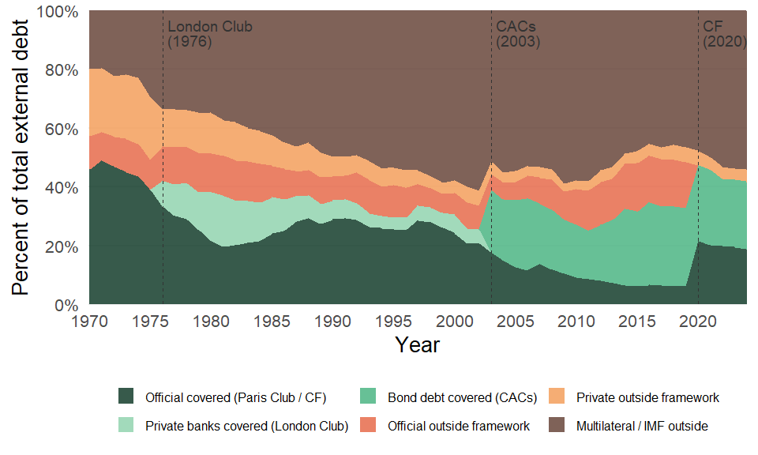

```r
p_lic <- make_chart(annual_lic)
p_mic <- make_chart(annual_mic)
p_all <- make_chart(annual_all)
p_all
```

```r
#p_lic
```

```r
p_mic
```

[output not shown]

```r
p_all
```

[output not shown]

# 15. Save charts

```r
ggsave(
  file.path(output_dir, "ex7_resolution_mechanisms_lic.png"),
  p_lic, width = 10, height = 6, dpi = 300
)
ggsave(
  file.path(output_dir, "ex7_resolution_mechanisms_mic.png"),
  p_mic, width = 10, height = 6, dpi = 300
)
ggsave(
  file.path(output_dir, "ex7_resolution_mechanisms_all.png"),
  p_all, width = 10, height = 6, dpi = 300
)
cat("Charts saved to:", output_dir, "\n")
```

# 16. Export to Excel

```r
wb_out <- createWorkbook()

# --- Normalized chart data (wide) ---
for (grp in c("LIC", "MIC", "All")) {
  annual_data <- switch(grp, LIC = annual_lic, MIC = annual_mic, All = annual_all)
  sheet_name  <- paste0("Chart - ", grp)

  addWorksheet(wb_out, sheet_name)
  writeData(wb_out, sheet_name,
    annual_data %>%
      select(year, mechanism, n_countries, median_share, pct_norm) %>%
      mutate(mechanism = as.character(mechanism)) %>%
      pivot_wider(
        names_from  = mechanism,
        values_from = c(median_share, pct_norm),
        values_fill = 0
      ) %>%
      arrange(year)
  )
}

# --- Country-level panel: the full panel_shares dataframe with covered flag ---
# Use this sheet to verify that individual countries are classified correctly
addWorksheet(wb_out, "Panel - country level")
writeData(wb_out, "Panel - country level",
  panel_shares %>%
    arrange(country_name, year, mechanism)
)

# --- Paris Club member reference ---
addWorksheet(wb_out, "PC Members")
writeData(wb_out, "PC Members", pc_mapping)

excel_file <- file.path(output_dir, "ex7_resolution_mechanisms.xlsx")
saveWorkbook(wb_out, excel_file, overwrite = TRUE)
cat("Excel saved:", excel_file, "\n")
```